# Ejercicios de VisualizaciÃ³n de Association Rules

## Algoritmo apriori: Minería de reglas de asociación

Apriori es un algoritmo que cuenta transacciones por medio de una estrategia orientada a nivel y por amplitud primero (en contraste con profundidad). Fue desarrollado por Agrawal y Srikant (1994). Se utiliza para generar reglas de asociación, identificar itemsets, itemsets de frecuencia máxima e itemsets de frecuencia cerrada.

Efectuaremos minería de reglas de asociación por medio del algoritmo Apriori implementado en arules.

Visualiza la salida de la consola de R para examinar la salida del algoritmo.

```r
rules <- apriori(myGroceries, parameter = list(support = 0.001, confidence = 0.05))
```

```
## Apriori
##
## Parameter specification:
##  confidence minval smax arem  aval originalSupport maxtime support minlen
##        0.05    0.1    1 none FALSE            TRUE       5   0.001      1
##  maxlen target  ext
##      10  rules TRUE
##
## Algorithmic control:
##  filter tree heap memopt load sort verbose
##     0.1 TRUE TRUE  FALSE TRUE    2    TRUE
##
## Absolute minimum support count: 7
##
## set item appearances ...[0 item(s)] done [0.00s].
## set transactions ...[168 item(s), 7868 transaction(s)] done [0.01s].
## sorting and recoding items ... [158 item(s)] done [0.00s].
## creating transaction tree ... done [0.01s].
## checking subsets of size 1 2 3 4 5 6 done [0.03s].
## writing ... [38649 rule(s)] done [0.01s].
## creating S4 object  ... done [0.03s].
```

```r
summary(rules)
```

```
## set of 38649 rules
##
## rule length distribution (lhs + rhs):sizes
##     1     2     3     4     5     6
##    29  3822 19789 12926  2005    78
##
##    Min. 1st Qu.  Median    Mean 3rd Qu.    Max.
##   1.000   3.000   3.000   3.344   4.000   6.000
##
## summary of quality measures:
##     support           confidence        coverage             lift
##  Min.   :0.001017   Min.   :0.0500   Min.   :0.001017   Min.   : 0.416
##  1st Qu.:0.001144   1st Qu.:0.1379   1st Qu.:0.003686   1st Qu.: 1.884
##  Median :0.001398   Median :0.2333   Median :0.006609   Median : 2.534
##  Mean   :0.002095   Mean   :0.2858   Mean   :0.012582   Mean   : 2.866
##  3rd Qu.:0.002034   3rd Qu.:0.3913   3rd Qu.:0.012710   3rd Qu.: 3.467
##  Max.   :0.255465   Max.   :1.0000   Max.   :1.000000   Max.   :34.712
##      count
##  Min.   :   8.00
##  1st Qu.:   9.00
##  Median :  11.00
##  Mean   :  16.48
##  3rd Qu.:  16.00
##  Max.   :2010.00
##
## mining info:
##         data ntransactions support confidence
##  myGroceries          7868   0.001       0.05
```

📝 **DOCUMENTO ARV-02**

Documenta los siguientes datos de la salida de arules:

- Número de reglas producidas.
- Distribución del tamaño de las reglas (lhs + rhs).
- Media aritmética de la distribución de reglas.

## Estructura de la clase rules

Examinaremos la estructura del objeto rules

```r
str(rules)
```

```
## Formal class 'rules' [package "arules"] with 4 slots
##   ..@ lhs    :Formal class 'itemMatrix' [package "arules"] with 3 slots
##   .. .. ..@ data       :Formal class 'ngCMatrix' [package "Matrix"] with 5 slots
##   .. .. .. .. ..@ i       : int [1:90588] 73 101 149 85 45 45 45 128 122 122 ...
##   .. .. .. .. ..@ p       : int [1:38650] 0 0 0 0 0 0 0 0 0 0 ...
##   .. .. .. .. ..@ Dim     : int [1:2] 169 38649
##   .. .. .. .. ..@ Dimnames:List of 2
##   .. .. .. .. .. ..$ : NULL
##   .. .. .. .. .. ..$ : NULL
##   .. .. .. .. ..@ factors : list()
##   .. .. ..@ itemInfo   :'data.frame':    169 obs. of  3 variables:
##   .. .. .. ..$ labels: chr [1:169] "frankfurter" "sausage" "liver loaf" "ham" ...
##   .. .. .. ..$ level2: Factor w/ 55 levels "baby food","bags",..: 44 44 44 44 44 44 44 42 42 41 ...
##   .. .. .. ..$ level1: Factor w/ 10 levels "canned food",..: 6 6 6 6 6 6 6 6 6 6 ...
##   .. .. ..@ itemsetInfo:'data.frame':    0 obs. of  0 variables
##   ..@ rhs    :Formal class 'itemMatrix' [package "arules"] with 3 slots
##   .. .. ..@ data       :Formal class 'ngCMatrix' [package "Matrix"] with 5 slots
##   .. .. .. .. ..@ i       : int [1:38649] 108 127 98 10 9 152 0 107 26 69 ...
##   .. .. .. .. ..@ p       : int [1:38650] 0 1 2 3 4 5 6 7 8 9 ...
##   .. .. .. .. ..@ Dim     : int [1:2] 169 38649
##   .. .. .. .. ..@ Dimnames:List of 2
##   .. .. .. .. .. ..$ : NULL
##   .. .. .. .. .. ..$ : NULL
##   .. .. .. .. ..@ factors : list()
##   .. .. ..@ itemInfo   :'data.frame':    169 obs. of  3 variables:
##   .. .. .. ..$ labels: chr [1:169] "frankfurter" "sausage" "liver loaf" "ham" ...
##   .. .. .. ..$ level2: Factor w/ 55 levels "baby food","bags",..: 44 44 44 44 44 44 44 42 42 41 ...
##   .. .. .. ..$ level1: Factor w/ 10 levels "canned food",..: 6 6 6 6 6 6 6 6 6 6 ...
##   .. .. ..@ itemsetInfo:'data.frame':    0 obs. of  0 variables
##   ..@ quality:'data.frame':  38649 obs. of  5 variables:
##   .. ..$ support   : num [1:38649] 0.0789 0.0501 0.0583 0.0513 0.0569 ...
##   .. ..$ confidence: num [1:38649] 0.0789 0.0501 0.0583 0.0513 0.0569 ...
##   .. ..$ coverage  : num [1:38649] 1 1 1 1 1 1 1 1 1 1 ...
##   .. ..$ lift      : num [1:38649] 1 1 1 1 1 1 1 1 1 1 ...
##   .. ..$ count     : int [1:38649] 621 394 459 404 448 410 459 631 418 453 ...
##   ..@ info   :List of 4
##   .. ..$ data         : symbol myGroceries
##   .. ..$ ntransactions: int 7868
##   .. ..$ support      : num 0.001
##   .. ..$ confidence   : num 0.05
```

La clase `rules` representa a un conjunto de reglas las cuales generalmente se crean por medio de la invocación de un algoritmo de minería de reglas de asociación como `apriori`. Las reglas almacenan el LHS y el RHS de forma separada como objetos de la clase `itemMatrix`.

Las reglas minadas típicamente contienen diversas mediciones de interés las cuales pueden accederse por medio del método `quality`. Es posible calcular mediciones adicionales por medio de `interestMeasure`

Obtenemos las primeras tres reglas respecto a la métrica lift, que es una métrica popular de la fortaleza de la regla.

```r
inspect(head(rules, n = 3, by = "lift"))
```

```
##     lhs                   rhs                         support confidence    coverage     lift count
## [1] {bottled beer,
##      red/blush wine}   => {liquor}                0.001525165  0.3750000 0.004067107 34.71176    12
## [2] {ham,
##      other vegetables,
##      white bread}      => {processed cheese}      0.001016777  0.4705882 0.002160651 28.04991     8
## [3] {hamburger meat,
##      soda}             => {Instant food products} 0.001398068  0.2244898 0.006227758 28.03628    11
```

Para conocer las medidas disponibles en el conjunto de reglas empleamos el método `quality`.

```r
head(quality(rules))
```

|  | support | confidence | coverage | lift | count |
| --- | --- | --- | --- | --- | --- |
| 1 | 0.07892730 | 0.07892730 | 1 | 1 | 621 |
| 2 | 0.05007626 | 0.05007626 | 1 | 1 | 394 |
| 3 | 0.05833757 | 0.05833757 | 1 | 1 | 459 |
| 4 | 0.05134723 | 0.05134723 | 1 | 1 | 404 |
| 5 | 0.05693950 | 0.05693950 | 1 | 1 | 448 |
| 6 | 0.05210981 | 0.05210981 | 1 | 1 | 410 |

Estas son las medidas generadas por omisión con el algoritmo Apriori. Para añadir otras mediciones es posible emplear la función `interestMeasures()` de la librería arules.

```r
args(getS3method("plot", "rules"))
```

```
## function (x, method = NULL, measure = "support", shading = "lift",
##     interactive = NULL, engine = "default", data = NULL, control = NULL,
##     ...)
## NULL
```

`x` representa el conjunto de reglas a ser vizualizadas, `method` es el método de visualización y `measure` y `shading` contienen las mediciones de interés empleadas por la gráfica. Por medio de `engine` es posible usar diversos motores de graficación para visualizar las reglas. El motor predeterminado típicamente usa `grid`, muchas gráficas pueden ser visualizadas con el motor "htmlwidget" en cual resulta en un widget HTML.

## Técnicas y ejemplos de visualización con arulesViz

### Scatter plot

Es posible lograr una visualización simple de reglas de asociación por medio de la gráfica scatter plot con dos medidas de interés en los ejes. El método por omisión de reglas de asociación en arulesViz es el scatter plot empleando support y confidence en los ejes. También se usa una tercera medición (lift, por omisión) como el color (o escala de grises de los puntos). Se incluye una escala del rango de valores que corresponde a los colores.

```
## To reduce overplotting, jitter is added! Use jitter = 0 to prevent jitter.
```

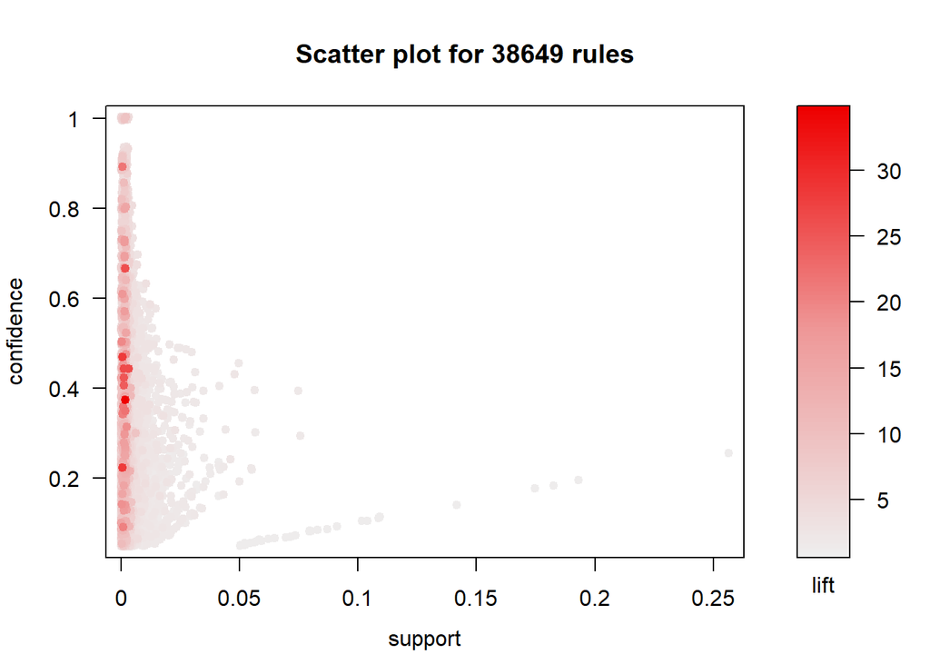

```r
plot(rules)
```

Es posible emplear en los ejes del scatter plot cualquier medición de calidad almacenada en el slot de calidad del conjunto de reglas (vector de longitud 2 para el parámetro measure) o para el gradiente de color (shading).

📜 **DOCUMENTO ARV-03**

Analiza la gráfica, identifica las reglas que tengan un valores altos en la medición lift e indica para ellas si el valor de support es alto o bajo.

💻 **EJERCICIO ARV-04**

Modifica el código de abajo para crear un scatter plot con las siguientes propiedades:

```
## To reduce overplotting, jitter is added! Use jitter = 0 to prevent jitter.
```

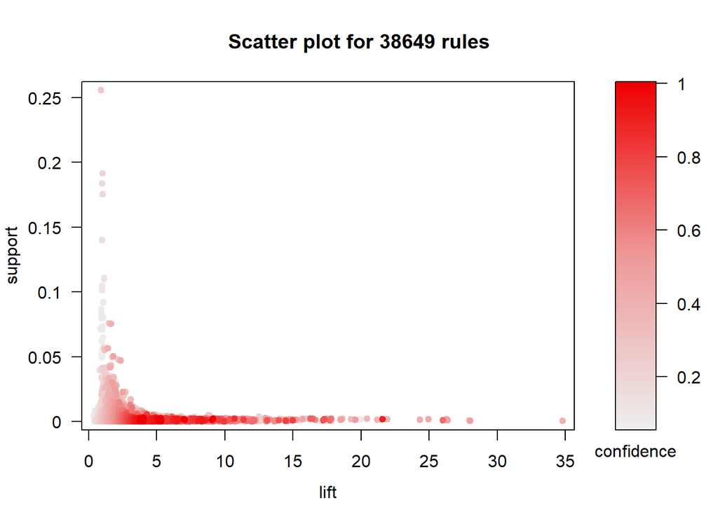

```r
#TODO: Asigna los parámetros a plot para:
# support en el eje horizontal (h-axis)
# lift en el eje vertical (v-xaix)
# confidence (measure) como gradiente de color (shading)

#plot(rules, measure = c("h-axis", "v-axis"), shading = "measure")
plot(rules, measure = c("lift", "support"), shading = "confidence")
```

💻 **EJERCICIO ARV-05**

```
## To reduce overplotting, jitter is added! Use jitter = 0 to prevent jitter.
```

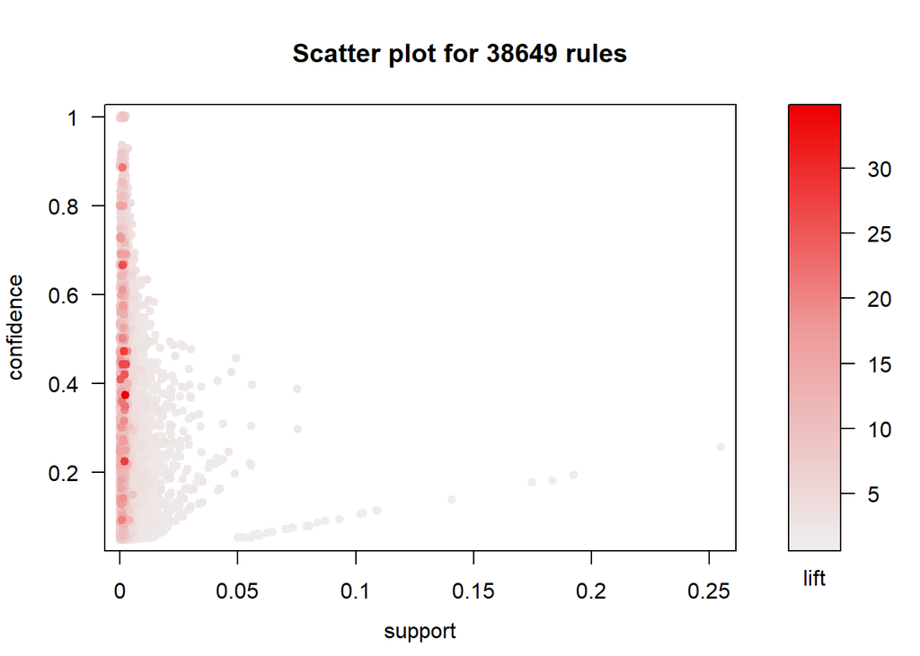

```r
#TODO: Scatter plot con support y confidence en los ejes horizontal y vertical, empleando coverage como medición asociada a la escala de colores

# Por omisión la gráficas scatter plot en arulesViz presentan support en el eje horizontal y confidence en el eje vertical

#plot(rules, shading="measure")
plot(rules, shading = "lift")
```

### Two-key plot

Introducida por Unwin, Hoffmann y Bernt (2001), el Two-key pllot es una versión especial de un scatter plot en la que support y confidence están asociados al eje horizontal y vertical y el color de los puntos indica el "orden" (número de elementos contenidos en la regla). Este tipo de gráficas pueden ser creadas por medio de la interfaz unificada.

```
## To reduce overplotting, jitter is added! Use jitter = 0 to prevent jitter.
```

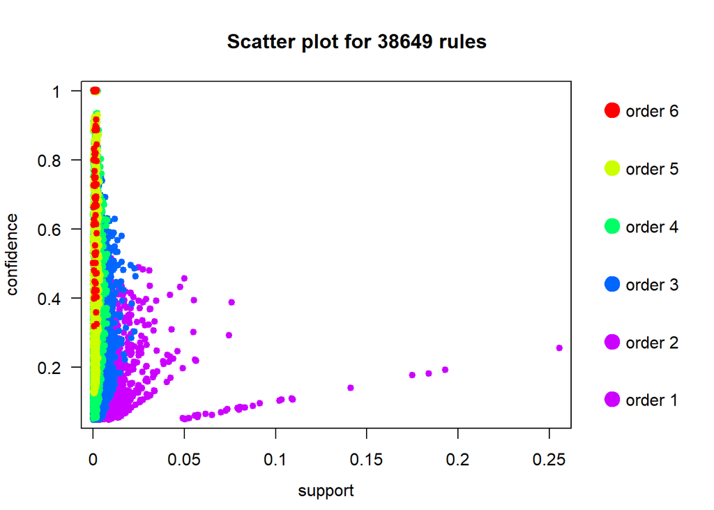

```r
plot(rules, method= "two-key plot")
```

📄 **DOCUMENTO ARV-04**

Responde: ¿Qué tipo de relación muestran order y support en esta visualización?

### Scatter plots interactivos en arulesViz

El método plot ofrece características interactivas para seleccionar reglas y mostrar mayor o menor detalle en la gráfica (zoom in y zoom out) las cuales son útiles tareas de exploración. La interacción se activa por medio del parámetro engine = "interactive".

```r
#sel <- plot(rules, measure = c("support", "lift"), shading = "confidence", interactive = TRUE)
```

Las funciones interactivas incluyen: - Inspeccionar reglas individuales al seleccionarlas y dar click al botón inspect. - Inspeccionar conjuntos de reglas al seleccionar una región rectangular de la gráfica y dar click en el botón inspect. - Mostrar mayor o menor detalle en una región seleccionada (botones zoom in / zoom out). - Regresar a la última selección para mayor análisis, (botón end).